# Proyecto Final

## Análisis predictivo utilizando técnicas de regresión

### Selección de Dataset

Haciendo una busqueda sobre los datos de TidyTuesday se identificaron los siguientes conjuntos de datos interesantes para considerar

| Dataset | Fecha | Descripción | Motivación |
| --- | --- | --- | --- |
| Stranger Things Dialogs | 2022-10-18 | Dialogos de las 4 temporadas de Stranger Things | Evidenciar una estrategia para mantener a la audiencia enganchada a través de los diálogos |
| Formula 1 Races | 2021-09-07 | Datos sobre las carreras, constructores y pilotos de Formula 1 | Determinar los factores que determinan una ventaja en un gran premio |
| Passwords | 2020-01-14 | Base de datos sobre contraseñas más populares de multiples "hackeos" | Análisis para la seguridad y fortaleza de distintas claves que podrían ser resistentes a ataques de fuerza bruta |
| Chess | 2024-10-01 | Compendio de jugadas memorables de ajedrez | Análisis sobre un árbol de jugadas en donde se podrían predecir varias estrategias para una victoria |
| Energy | 2023-06-06 | Datos sobre producción energética por país | Contiene muchos datos para establecer correlaciones y poder hacer regresiones |
| Ultra Trail Running | 2021-10-26 | Datos de las competencias de Ultra Trail Running | Contiene varios parametros de corredores y carreras que podrían analizarse |

Tanto los conjuntos de datos de **Carreras de Formula1** como **Ultra Trail Running** por los aspectos registrados en sus tablas representan una gran relevancia y oportunidad para hacer un análisis de regresiones que nos puedan dar conclusiones interesantes. Al final se seleccionó el dataset de **Ultra Trail Running** para el proyecto por dos razones:

- Procesamiento inicial de datos es más simple lo que permitirá enfocar el análisis en las regresiones mas que en el tratamiento inicial de los datos.
- Un tema de gusto personal y afinidad con el deporte.

### Procesamiento de Datos

El dataset nos provee de dos archivos de bases de datos

#### `ultra_rankings.csv`

| Campo | Tipo | Descripción |
| --- | --- | --- |
| race_year_id | double | Race ID |
| rank | double | Rank del corredor |
| runner | string | Nombre del corredor |
| time | double | Tiempo del corredor, hour:minute:seconds |
| age | double | Edad |
| gender | string | Género (Hombre = M, Mujer = W) |
| nationality | string | Nacionalidad del corredor |

#### `race.csv`

| Campo | Tipo | Descripción |
| --- | --- | --- |
| race_year_id | double | Race ID (FK) |
| event | string | Nombre del Evento |
| race | string | Nombre de la competencia |
| city | string | Nombre de la ciudad |
| country | string | Nombre del País |
| date | double | Fecha |
| start_time | double | Hora de inicio |
| participation | character | Modalidad o tipo de participación |
| distance | double | Distancia en Km |
| elevation_gain | double | Desnivel positivo en metros |
| elevation_loss | double | Desnivel negativo en metros |
| aid_stations | double | Número de estaciones de ayuda |
| participants | double | Número total de participantes |

```python
# print(races[(races['distance'] < 100)])
races = races[(races['distance'] > 100)]
print(races.loc[:, races.columns != 'race_year_id'].describe())
```

```
         distance  elevation_gain  elevation_loss  aid_stations  participants
count  599.000000      599.000000      599.000000    599.000000    599.000000
mean   163.379416     5763.353923    -5797.375626     11.991653    234.806344
std      4.733222     2678.892467     2710.972938      5.698230    357.430269
min    128.600000      110.000000   -14440.000000      0.000000      1.000000
25%    160.500000     3632.500000    -7585.000000      9.000000     75.000000
50%    162.600000     5730.000000    -5740.000000     13.000000    150.000000
75%    166.450000     7575.000000    -3670.000000     15.000000    300.000000
max    175.000000    14430.000000     -110.000000     41.000000   2900.000000
```

```python
ultra_rankings.loc[:, ultra_rankings.columns != 'race_year_id'].describe()
```

|  | rank | age | time_in_seconds |
| --- | --- | --- | --- |
| count | 57396.000000 | 70693.000000 | 57396.000000 |
| mean | 301.174106 | 45.354052 | 126748.894174 |
| std | 445.585236 | 9.041663 | 35993.871607 |
| min | 1.000000 | 0.000000 | 15174.000000 |
| 25% | 31.000000 | 39.000000 | 98857.000000 |
| 50% | 93.000000 | 45.000000 | 121818.500000 |
| 75% | 317.000000 | 51.000000 | 153128.250000 |
| max | 1962.000000 | 133.000000 | 296806.000000 |

```python
print(ultra_rankings.drop('race_year_id', axis=1).describe())
```

```
               rank           age  time_in_seconds          male        female
count  57396.000000  70693.000000     57396.000000  70693.000000  70693.000000
mean     301.174106     45.495084    126748.894174      0.855261      0.144385
std      445.585236      8.656965     35993.871607      0.351839      0.351482
min        1.000000      5.000000     15174.000000      0.000000      0.000000
25%       31.000000     39.000000     98857.000000      1.000000      0.000000
50%       93.000000     45.000000    121818.500000      1.000000      0.000000
75%      317.000000     51.000000    153128.250000      1.000000      0.000000
max     1962.000000     80.000000    296806.000000      1.000000      1.000000
```

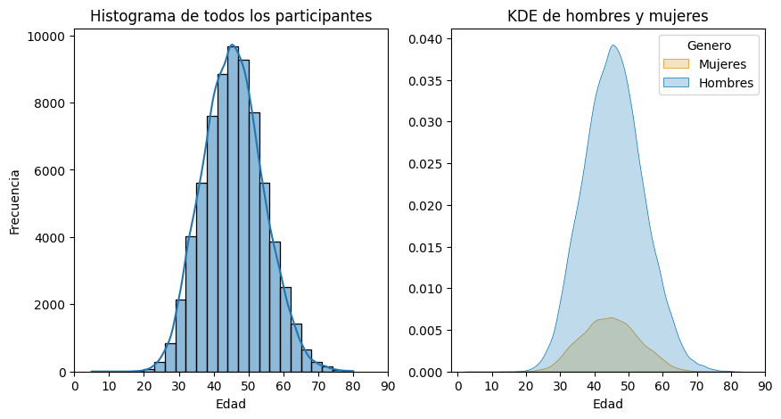

```python
import matplotlib.pyplot as plt
import seaborn as sns

fig, axs = plt.subplots(nrows=1, ncols=2, figsize=(10, 5))
sns.histplot(data=ultra_rankings, x="age", bins=25, ax=axs[0], kde=True)
sns.kdeplot(
    data=ultra_rankings[["gender", "age"]],
    x="age",
    ax=axs[1],
    hue="gender",
    fill=True,
    palette="colorblind",
    linewidth=0.5,
)

axs[0].set_title("Histograma de todos los participantes")
axs[1].set_title("KDE de hombres y mujeres")
axs[0].set_xlabel("Edad")
axs[1].set_xlabel("Edad")
axs[0].set_ylabel("Frecuencia")
axs[1].set_ylabel("")
axs[0].set_xticks(np.arange(0, 100, 10))
axs[1].set_xticks(np.arange(0, 100, 10))
plt.legend(title='Genero', loc='upper right', labels=['Mujeres', 'Hombres'])
plt.show()

plt.tight_layout()
```

La mayoria de participantes se encuentran alrededor de los 45 años, siendo tambien la mayoria de los participantes hombres. La distribucion de edades de las mujeres esta ligeramente sesgada a la izquierda comparada a los hombres

### Predicciones

#### Caso 1: Predicción de tendendencia de crecimiento

A pesar de que el trail running se ha venido practicando durante muchos años, el ultra trail running ha empezado su crecimiento solo en la última decada y en algunos paises, principalmente de Sudamérica, ha sido solo hasta hace muy poco que se ha vuelto popular en grupos reducidos de atletas. Este hecho sugiere hacer un estudio sobre la tendencia a través de los años de la participación por pais y ver los países que han tenido el mayor crecimiento en el tiempo.

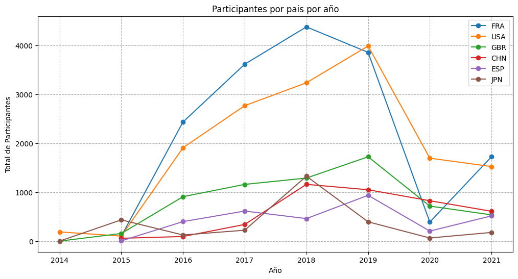

```python
# Se filtra top 6 países con mas participantes para graficar
top_nationalities = (
    ultra_rankings.groupby("nationality")
    .size()
    .reset_index(name="count")
    .sort_values(by="count", ascending=False)
    .head(6)["nationality"]
    .to_list()
)

# Combinamos la tabla de carreras con la tabla de ultra_rankings
ultra_df = ultra_rankings.merge(races, "inner", "race_year_id")

# Calculamos el año basado en el campo 'date'
ultra_df["date_dt"] = pd.to_datetime(ultra_df["date"])
ultra_df["year"] = ultra_df["date_dt"].dt.year

# Agrupamos por pais y año
ultra_df_by_nationality_year = (
    ultra_df.groupby(["nationality", "year"])
    .size()
    .reset_index(name="total_participants")
).sort_values(by="year")

plt.figure(figsize=(12, 6))
for nationality in top_nationalities:
    df_nationality = ultra_df_by_nationality_year[
        ultra_df_by_nationality_year["nationality"] == nationality
    ]
    plt.plot(
        df_nationality["year"],
        df_nationality["total_participants"],
        "o-",
        label=nationality,
    )

plt.xlabel("Año")
plt.ylabel("Total de Participantes")
plt.title("Participantes por pais por año")
plt.grid(visible=True, linestyle="dashed")
plt.legend()
```

```python
from scipy import stats
import warnings

warnings.filterwarnings("ignore", category=RuntimeWarning)
data = []
for nationality in ultra_df_by_nationality_year["nationality"].astype("str").unique():
    ultra_df_group = ultra_df_by_nationality_year[
        (ultra_df_by_nationality_year["nationality"] == nationality)
        & (ultra_df_by_nationality_year["year"] <= 2019)
    ]
    if ultra_df_group.empty:
        continue
    model = stats.linregress(
        ultra_df_group["year"], ultra_df_group["total_participants"]
    )
    data.append([nationality, model.slope, model.stderr, model.rvalue**2])

df_stats = pd.DataFrame(
    data, columns=["nationality", "slope", "stderr", "r_squared"]
).sort_values(by="slope", ascending=False)

df_stats.describe()
```

|  | slope | stderr | r_squared |
| --- | --- | --- | --- |
| count | 97.000000 | 97.000000 | 121.000000 |
| mean | 43.196160 | 10.985313 | 0.491135 |
| std | 135.909158 | 34.767719 | 0.405793 |
| min | -2.000000 | 0.000000 | 0.000000 |
| 25% | 0.500000 | 0.305505 | 0.000000 |
| 50% | 4.200000 | 2.121320 | 0.600000 |
| 75% | 19.700000 | 7.461794 | 0.898993 |
| max | 944.500000 | 300.704811 | 1.000000 |

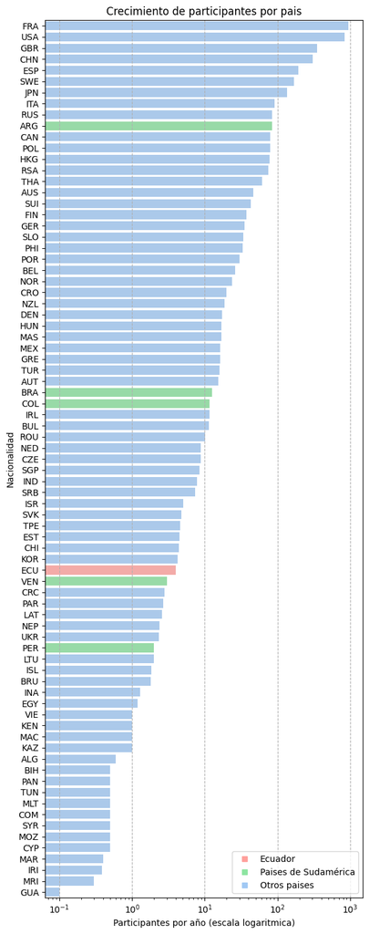

```python
import matplotlib.lines as mlines

# warnings.filterwarnings("ignore", category=FutureWarning)

f, ax = plt.subplots(figsize=(6, 15))
sns.set_color_codes("pastel")
colors = [
    (
        "r"
        if (nationality == "ECU")
        else (
            "g"
            if nationality
            in [
                "ARG",
                "BOL",
                "BRA",
                "CHL",
                "COL",
                "FLK",
                "GUF",
                "GUY",
                "PRY",
                "PER",
                "SUR",
                "URY",
                "VEN",
            ]
            else "b"
        )
    )
    for nationality in df_stats[df_stats["slope"] > 0]["nationality"].to_list()
]
barplot = sns.barplot(
    x="slope",
    y="nationality",
    data=df_stats[df_stats["slope"] > 0],
    label="Pendientes",
    palette=colors,
    hue="nationality",
)
# Seteando scala logaritmica en x para visualizar los datos de mejor manera
barplot.set_xscale("log")
barplot.set_title("Crecimiento de participantes por pais")
barplot.set_ylabel("Nacionalidad")
barplot.set_xlabel("Participantes por año (escala logaritmica)")

barplot.axes.grid(True, axis="x", linestyle="--")

ecu_legend_handle = mlines.Line2D([], [], color="r", marker="s", ls="", label="Ecuador")
south_america_legend_handle = mlines.Line2D(
    [], [], color="g", marker="s", ls="", label="Paises de Sudamérica"
)
other_legend_handle = mlines.Line2D(
    [], [], color="b", marker="s", ls="", label="Otros paises"
)
legend = barplot.legend(
    handles=[ecu_legend_handle, south_america_legend_handle, other_legend_handle]
)

f.tight_layout()
```

#### Caso 2: Predicción de tiempo de carrera

Poder predecir el tiempo de un participante para terminar una competencia es de gran interes tanto para los atletas como para el desarrollo de la ciencia del deporte. Hay muchos factores que influyen en el éxito o fracaso de una participación en una competencia de ultra trail. Ademas de la edad, el género,influyen factores internos como alimentación e hidratación antes y durante la competencia, entrenamiento y descanso previo. También influyen factores externos como condiciones climaticas, nivel técnico del terreno, disponibilidad de estaciones de ayuda.

A pesar de estas variables que no estan provistas en los datos que tenemos vamos a realizar predicciones del tiempo sobre los datos que tenemos como son:

- Edad
- Género
- Distancia total
- Desnivel positivo
- Desnivel negativo
- Estaciones de ayuda

Si se grafica la distribución del tiempo en horas para cada una de los factores obtenemos lo siguiente:

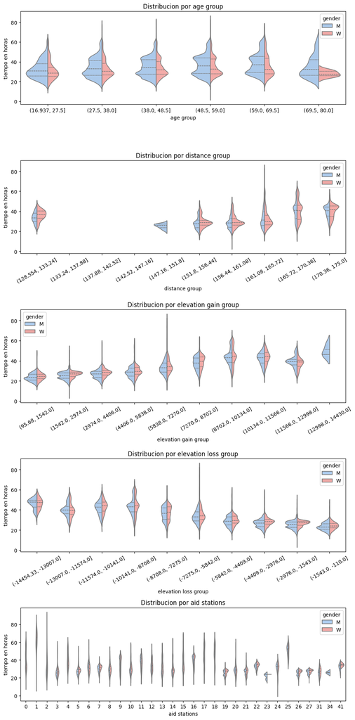

```python
ultra_df_finishers = ultra_df[
    ultra_df["time"].notna() & ultra_df["time"] > 0 & ultra_df["rank"].notna()
]

columns = [
    "aid_stations",
    "age",
    "distance",
    "elevation_gain",
    "elevation_loss",
    "gender",
    "male",
    "female",
    "time_in_seconds",
]
ultra_df_data = ultra_df_finishers[columns]
ultra_df_data["time_in_hours"] = ultra_df_data["time_in_seconds"] / 3600

ultra_df_data.insert(
    loc=0, column="age_group", value=pd.cut(ultra_df_data["age"], bins=6)
)
ultra_df_data.insert(
    loc=1, column="distance_group", value=pd.cut(ultra_df_data["distance"], bins=10)
)
ultra_df_data.insert(
    loc=2,
    column="elevation_gain_group",
    value=pd.cut(ultra_df_data["elevation_gain"], bins=10),
)
ultra_df_data.insert(
    loc=3,
    column="elevation_loss_group",
    value=pd.cut(ultra_df_data["elevation_loss"], bins=10),
)

fig, axes = plt.subplots(nrows=5, ncols=1, figsize=(10, 20))
axes = axes.flatten()

for i, feature in enumerate(ultra_df_data.columns.to_list()[:5]):
    sns.violinplot(
        data=ultra_df_data,
        x=feature,
        y="time_in_hours",
        hue="gender",
        split=True,
        inner="quart",
        ax=axes[i],
        palette={"M": "b", "W": "r"},
    )
    if (
        feature == "distance_group"
        or feature == "elevation_gain_group"
        or feature == "elevation_loss_group"
    ):
        axes[i].tick_params(axis="x", rotation=30)
    axes[i].set_title(f"Distribucion por {feature.replace('_', ' ')}")
    axes[i].set_xlabel(feature.replace("_", " "))
    axes[i].set_ylabel("tiempo en horas")

plt.tight_layout()
```

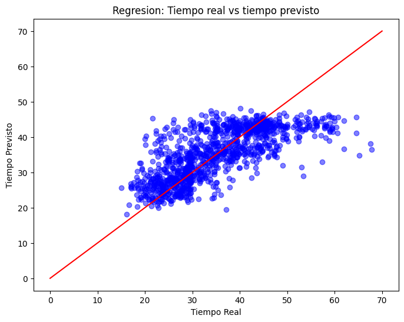

```python
from sklearn.linear_model import LinearRegression
import matplotlib.pyplot as plt

modelo = LinearRegression()
modelo.fit(X=X_train, y=y_train)

y_pred = modelo.predict(X=X_test)

plt.figure(figsize=(8, 6))
plt.scatter(x=y_test, y=y_pred, color="blue", alpha=0.5)
plt.plot([0, 70], [0, 70], color="red")
plt.xlabel("Tiempo Real")
plt.ylabel("Tiempo Previsto")
plt.title("Regresion: Tiempo real vs tiempo previsto")
```

```python
from sklearn.metrics import root_mean_squared_error
RMSE = root_mean_squared_error(y_true=y_test, y_pred=y_pred)
print(f"RMSE: {RMSE:.2f} horas")
```

```
RMSE: 6.99 horas
```

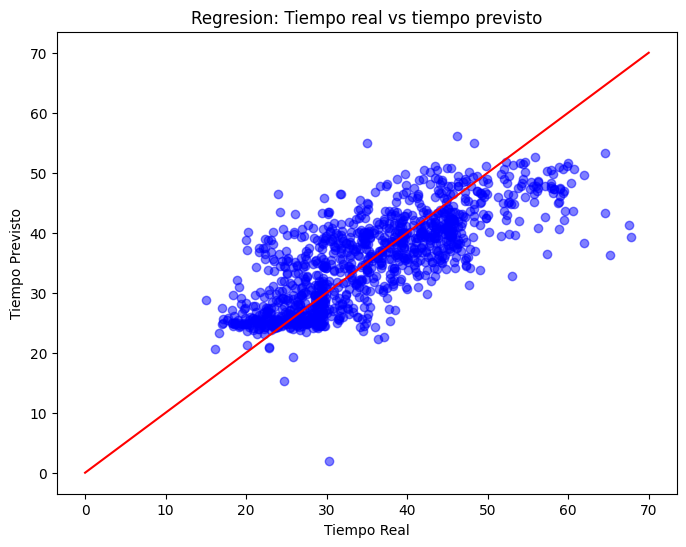

```python
from sklearn.preprocessing import PolynomialFeatures

poly = PolynomialFeatures(degree=5)

X_poly_train = poly.fit_transform(X_train)
X_poly_test = poly.transform(X_test)

modelo = LinearRegression()
modelo.fit(X=X_poly_train, y=y_train)

y_pred = modelo.predict(X=X_poly_test)

# Real vs Prediccion
plt.figure(figsize=(8, 6))
plt.scatter(x=y_test, y=y_pred, color="blue", alpha=0.5)
plt.plot([0, 70], [0, 70], color="red")
plt.xlabel("Tiempo Real")
plt.ylabel("Tiempo Previsto")
plt.title("Regresion: Tiempo real vs tiempo previsto")
```

```python
RMSE = root_mean_squared_error(y_true=y_test, y_pred=y_pred)
print(f"RMSE: {RMSE:,.2f} horas")
```

```
RMSE: 6.48 horas
```

```python
test_data = GenericDataset(
    data_test, target_name="time_in_hours", mode="test", task="reg"
)
test_loader = DataLoader(test_data, batch_size=3000)

with torch.no_grad():
    reales = []
    pred = []

    for datos in test_loader:
        X_test = datos["X"].to(device)
        y_test = datos["y"].to(device)

        y_pred = model(X_test)
        rmse = root_mean_squared_error(y_test.cpu(), y_pred.cpu())

        for elemento in y_test.flatten().cpu().numpy():
            reales.append(elemento)

        for elemento in y_pred.flatten().cpu().numpy():
            pred.append(elemento)

        print(f"RMSE: {rmse:,.2f} horas")
```

```
RMSE: 6.41 horas
```

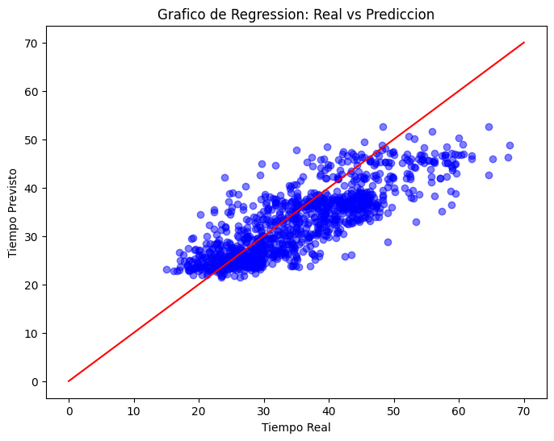

```python
plt.figure(figsize=(8, 6))
plt.scatter(reales, pred, color="blue", alpha=0.5)
plt.plot([0, 70], [0, 70], color="red")

plt.xlabel("Tiempo Real")
plt.ylabel("Tiempo Previsto")
plt.title("Grafico de Regression: Real vs Prediccion")
```